# Análisis Inteligente de Datos

Trabajo Final

Di Carlo, Suarez y Gómez

Febrero 2021

## Introducción

Este reporte contiene información referida a la carrera musical del artista Argentino Charly García. Previamente hemos consolidado todo su historial de canciones (tanto solistas como en bandas) en un archivo llamado resultado.txt cargado como ‘df_charly’. Asimismo, utilizaremos para el análisis un archivo llamado Albums.xlsx que contiene una marca que indica la categoría de cada uno de los álbumes de Charly García y un último archivo que contiene el Top 99 de mejores canciones del artista. Toda la información ha sido obtenida de la popular plataforma musical Spotify. Luego de trabajar nuestro archivo incorporando toda esta información antes mencionada, nuestro data frame de trabajo tiene la siguiente estructura:

| variable | classe | primeros_valores |
| --- | --- | --- |
| album_id | integer | 01SHGcb4X59QOezJ2MhqJx, 01SHGcb4X59QOezJ2MhqJx, 01SHGcb4X59QOezJ2MhqJx, 01SHGcb4X59QOezJ2MhqJx, 01SHGcb4X59QOezJ2MhqJx, 01SHGcb4X59QOezJ2MhqJx |
| nombre | integer | Mr. Jones o Pequeña Semblanza de una Familia Tipo Americana, Lunes Otra Vez, Tribulaciones, Lamento y Ocaso de un Tonto Rey Imaginario o No, Bienvenidos al Tren, Confesiones de Invierno, Un Hada, un C… |
| Top_cien | character | SI, SI, NO, SI, SI, NO |
| numero_cancion | integer | 8, 6, 9, 2, 4, 3 |
| numero_disco | integer | NA, NA, NA, NA, NA, NA |
| nombre_album | integer | Confesiones De Invierno, Confesiones De Invierno, Confesiones De Invierno, Confesiones De Invierno, Confesiones De Invierno, Confesiones De Invierno |
| artista_album | integer | Sui Generis, Sui Generis, Sui Generis, Sui Generis, Sui Generis, Sui Generis |
| id | integer | 7s8fyaidK2GOeM40SitjhO, 7DCumXCLeMSqX8cnMA6ud2, 4gyCJBCr4RY1VVe6sSDmyH, 1aXdFFTTUBMdcKsAX2q3vq, 47im9FzRfqAS2KYvw3NhSw, 0DXNPAmAhQ872qL8AWkgsk |
| bailabilidad | double | 0.528, 0.617, 0.327, 0.433, 0.476, 0.262 |
| energia | double | 0.717, 0.44, 0.164, 0.367, 0.148, 0.223 |
| tono_cancion | integer | 1, 7, 3, 7, 2, 2 |
| volumen | double | -10.335, -12.251, -15.471, -14.091, -15.794, -14.643 |
| modo | integer | 0, 1, 0, 1, 1, 1 |
| oralidad | double | 0.0532, 0.0386, 0.0337, 0.0304, 0.0313, 0.032 |
| acustica | double | 0.113, 0.059, 0.722, 0.0466, 0.791, 0.143 |
| instrumentalidad | double | 0.00279, 0, 0, 0.00000377, 0, 0.00122 |
| vivocidad | double | 0.2, 0.184, 0.124, 0.347, 0.0602, 0.083 |
| positividad | double | 0.925, 0.768, 0.125, 0.481, 0.261, 0.118 |
| tempo | double | 139.05, 122.879, 122.875, 125.524, 97.847, 174.071 |
| duracion_ms | integer | 104373, 190200, 358973, 194333, 245333, 385840 |
| compas | integer | 4, 4, 4, 3, 4, 3 |
| uri | integer | spotify:track:7s8fyaidK2GOeM40SitjhO, spotify:track:7DCumXCLeMSqX8cnMA6ud2, spotify:track:4gyCJBCr4RY1VVe6sSDmyH, spotify:track:1aXdFFTTUBMdcKsAX2q3vq, spotify:track:47im9FzRfqAS2KYvw3NhSw, spotify:tr… |
| url | integer | https://api.spotify.com/v1/audio-analysis/7s8fyaidK2GOeM40SitjhO, https://api.spotify.com/v1/audio-analysis/7DCumXCLeMSqX8cnMA6ud2, https://api.spotify.com/v1/audio-analysis/4gyCJBCr4RY1VVe6sSDmyH, ht… |
| categoria_album | character | estudio_suigeneris, estudio_suigeneris, estudio_suigeneris, estudio_suigeneris, estudio_suigeneris, estudio_suigeneris |

*Tabla 1 - Estructura de la tabla principal*

Antes de seccionar las variables echamos un vistazo a sus características y anticipamos algunos resultados:

|  | bail. | energia | tono_cancion | vol | modo | oral | acus. | instr. | vivo. | positividad | tempo | dur. |
| --- | --- | --- | --- | --- | --- | --- | --- | --- | --- | --- | --- | --- |
| cant_valores | 578.0 | 578.0 | 578 | 578 | 578.0 | 578.0 | 578.0 | 578.0 | 578.0 | 578.0 | 578 | 578 |
| cant_nulos | 0.0 | 0.0 | 88 | 0 | 135.0 | 0.0 | 0.0 | 69.0 | 0.0 | 1.0 | 0 | 0 |
| cant_NA | 0.0 | 0.0 | 0 | 0 | 0.0 | 0.0 | 0.0 | 0.0 | 0.0 | 0.0 | 0 | 0 |
| min | 0.1 | 0.0 | 0 | -43 | 0.0 | 0.0 | 0.0 | 0.0 | 0.0 | 0.0 | 47 | 19467 |
| max | 0.9 | 1.0 | 11 | -3 | 1.0 | 0.5 | 1.0 | 1.0 | 1.0 | 1.0 | 210 | 1648600 |
| rango | 0.8 | 1.0 | 11 | 40 | 1.0 | 0.5 | 1.0 | 1.0 | 1.0 | 1.0 | 162 | 1629133 |
| suma | 290.4 | 290.5 | 2855 | -6952 | 443.0 | 29.9 | 213.1 | 70.8 | 161.8 | 243.3 | 67348 | 139117420 |
| mediana | 0.5 | 0.5 | 5 | -11 | 1.0 | 0.0 | 0.3 | 0.0 | 0.2 | 0.4 | 115 | 225294 |
| media | 0.5 | 0.5 | 5 | -12 | 0.8 | 0.1 | 0.4 | 0.1 | 0.3 | 0.4 | 116 | 240688 |

*Tabla 2 - Medidas resúmenes de las variables numéricas*

Vemos una matriz de correlaciones entre nuestras variables numéricas para poder entender cómo se relacionan unas con otras:

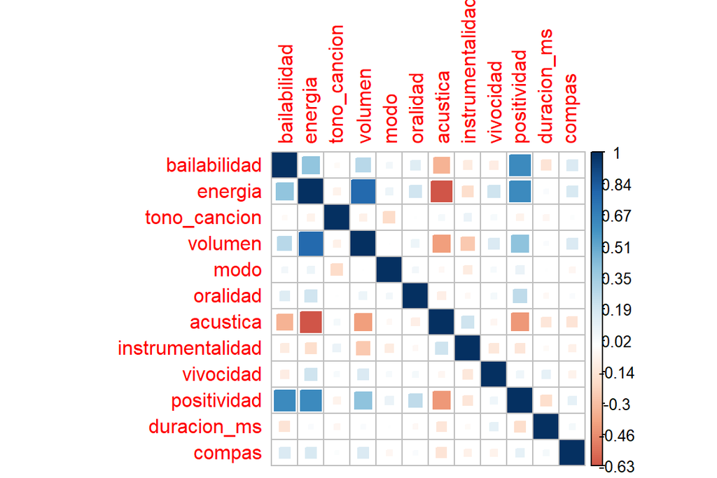

El objetivo de este análisis es intentar comprender qué variables hacen que una canción sea exitosa o no. Si bien no sabemos si contamos con la información suficiente como para determinarlo en base a las variables seleccionadas, intentaremos entenderlo. Por otra parte, además de las variables numéricas seleccionadas anteriormente, decidimos modificar dos variables más para poder mejorar nuestro análisis. A la variable numérica vivocidad decidimos dicotomizarla, considerando valor 0 si el valor real es menos de 0.5 y a 1 en caso contrario. Finalmente a la variable categórica categoria_album decidimos agruparla dejándola con 4 niveles posibles: estudio, otros, recop y vivo.

Debemos aclarar que, si bien nuestro archivo de éxitos contenía 99 canciones, no hemos utilizado las 99 por el modo en que estaban escritos sus nombres, sino que utilizamos 88 para marcar nuestras canciones. Las 11 restantes tenían una clave (el nombre) que no coincidía con ninguna de las observaciones de nuestro df_charly.

| nombre | Top_cien | categoria_album_a | nombre_album | artista_album | vivocidad_dis | energia | acustica | duracion_ms | positividad |
| --- | --- | --- | --- | --- | --- | --- | --- | --- | --- |
| Mr. Jones o Pequeña Semblanza de una Familia Tipo Americana | SI | estudio | Confesiones De Invierno | Sui Generis | 0 | 0.7 | 0.1 | 104373 | 0.9 |
| Lunes Otra Vez | SI | estudio | Confesiones De Invierno | Sui Generis | 0 | 0.4 | 0.1 | 190200 | 0.8 |
| Tribulaciones, Lamento y Ocaso de un Tonto Rey Imaginario o No | NO | estudio | Confesiones De Invierno | Sui Generis | 0 | 0.2 | 0.7 | 358973 | 0.1 |
| Bienvenidos al Tren | SI | estudio | Confesiones De Invierno | Sui Generis | 0 | 0.4 | 0.0 | 194333 | 0.5 |
| Confesiones de Invierno | SI | estudio | Confesiones De Invierno | Sui Generis | 0 | 0.1 | 0.8 | 245333 | 0.3 |
| Un Hada, un Cisne | NO | estudio | Confesiones De Invierno | Sui Generis | 0 | 0.2 | 0.1 | 385840 | 0.1 |

*Tabla 3 - Estructura de tabla con columnas seleccionadas*

## Resultados

### Frecuencias

#### Por categoría

| Categoría | frecuencia |
| --- | --- |
| estudio | 296 |
| recop | 168 |
| vivo | 107 |
| otros | 7 |

*Tabla 4 - Cantidad de canciones por categoría de Album*

#### Por artista

| Artista_album | frecuencia |
| --- | --- |
| Charly García | 280 |
| Sui Generis | 140 |
| Serú Girán | 122 |
| La Máquina de Hacer Pájaros | 15 |
| PorSuiGieco | 12 |
| Billy Bond and The Jets | 9 |

*Tabla 5 - Cantidad de canciones por Artista*

### Frecuencias conjuntas

| categoria_album_a | nombre_album | artista_album | frecuencia |
| --- | --- | --- | --- |
| recop | Cuarenta Obras Fundamentales (Volumen 1) | Charly García | 20 |
| recop | Cuarenta Obras Fundamentales (Volumen 2) | Charly García | 20 |
| estudio | La Hija De La Lagrima | Charly García | 20 |
| estudio | Yendo De La Cama Al Living | Charly García | 20 |
| vivo | Seru Giran (En Vivo) | Serú Girán | 20 |
| vivo | Yo No Quiero Volverme Tan Loco | Serú Girán | 20 |
| recop | Obras Cumbres | Sui Generis | 20 |
| vivo | Si - Detrás De Las Paredes | Sui Generis | 20 |
| recop | Sí o Sí - Diario del Rock Argentino - Sui Generis | Sui Generis | 20 |
| recop | Grandes Éxitos | Serú Girán | 19 |
| estudio | Sinfonía Para Adolescentes | Sui Generis | 19 |

*Tabla 6 - Top de frecuencias conjuntas por Categoría de Album, Album y Artista*

Se clarifica que no hay otras empatadas en 19.

### Visualizaciones

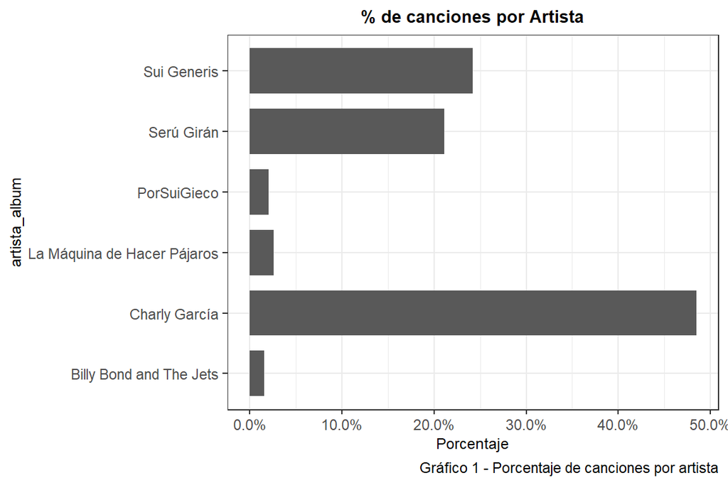

Aquí vemos que casi el 50% de canciones de Charly son como solista. Dentro de sus bandas, Sui Generis y Serú Giran son las dos con más canciones. Analizamos ahora qué artistas han tenido mayor impacto, viendo la cantidad de canciones exitosas (forman parte del top 88).

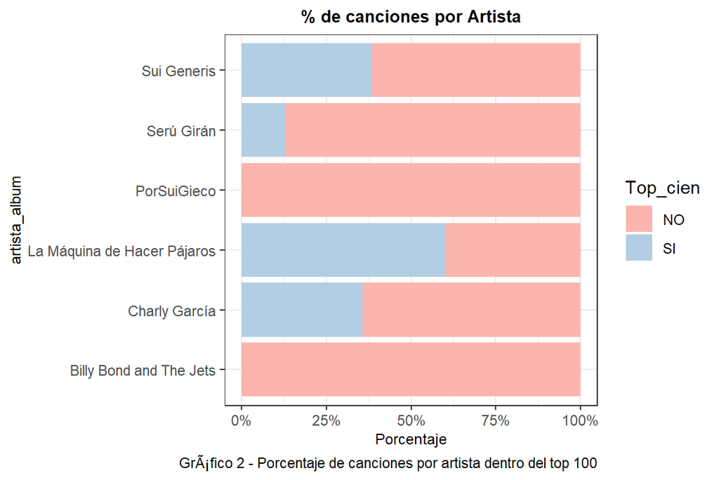

En el gráfico anterior se observa el porcentaje de canciones que han tenido éxito por artista. Esto nos permite entender cuáles son las bandas que tuvieron mejor reconocimiento, teniendo en cuenta la totalidad de sus canciones.

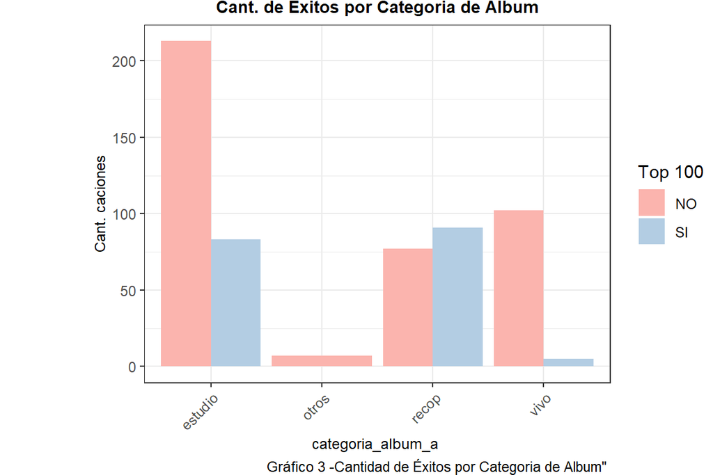

Un álbum de estudio es un álbum musical consistente en una selección de canciones grabadas en un estudio de grabación. La diferencia de un álbum de estudio con un álbum recopilatorio (el cual también suele contener canciones de estudio), es que el álbum de estudio incluye temas nuevos grabados por el artista, mientras que el recopilatorio, precisamente compila material publicado con anterioridad y ya conocido. Un punto común en estas dos categorías es la cantidad de canciones exitosas, por lo cual se podría verificar si son las mismas canciones. Además, al observar que la categoría de los albúmenes recopiladores tiene aproximadamente la misma cantidad de canciones reconocidas como no reconocidas vemos como se organizan en cada álbum.

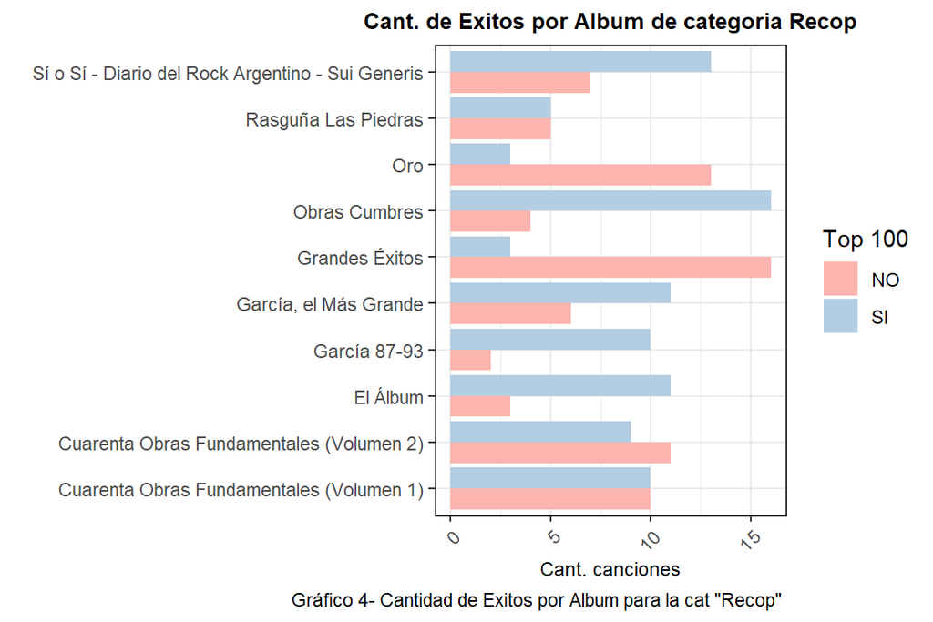

De este gráfico podemos concluir que en la mayoría de los álbumes recopilatorios las canciones reconocidas se combinan con las no reconocidas superando la mitad del álbum. Esto puede ser una estrategia de venta.

Para entender el comportamiento que tiene las variables cuantitativas seleccionadas con respecto a las variables cualitativas comenzamos realizando un BoxPlot:

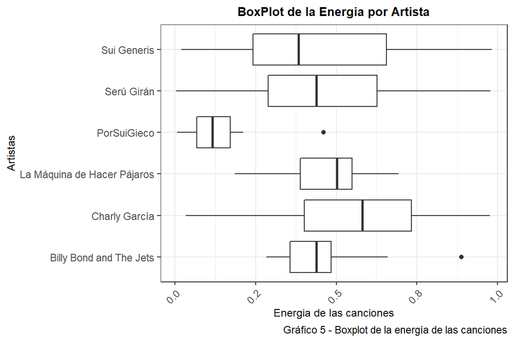

Aquí podemos ver como la banda PorSuiGieco tiene una energía notablemente menor que el resto.

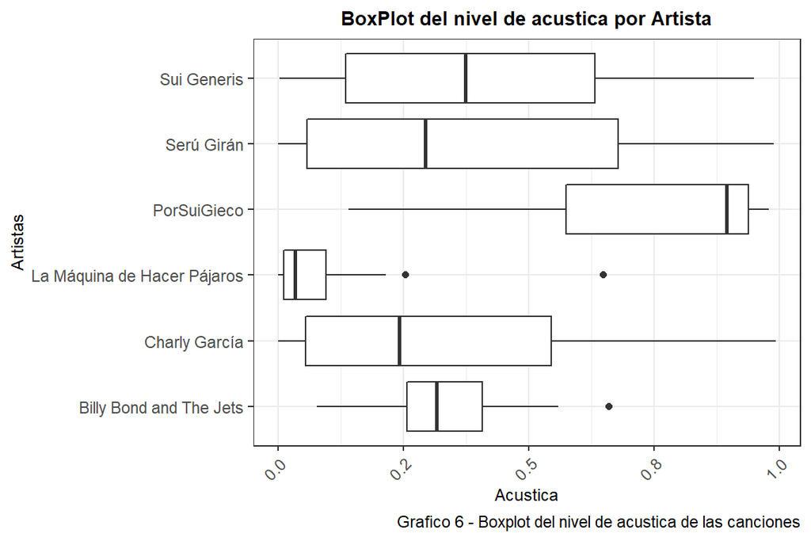

Este boxplot nos muestra que LMDHP tiene un nivel de acústica menor que el resto. En el otro extremo se encuentra PorSuiGieco con un nivel de acústica alto.

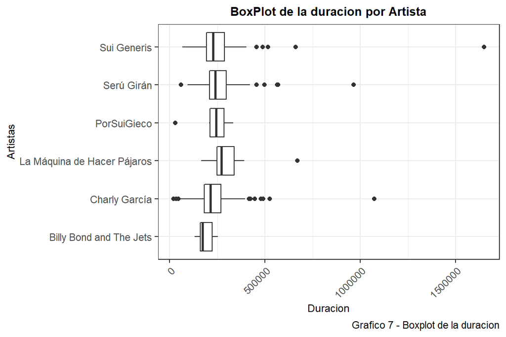

Este boxplot no nos muestra ninguna cuestión atípica en cuando a la duración de las canciones por cada artista.

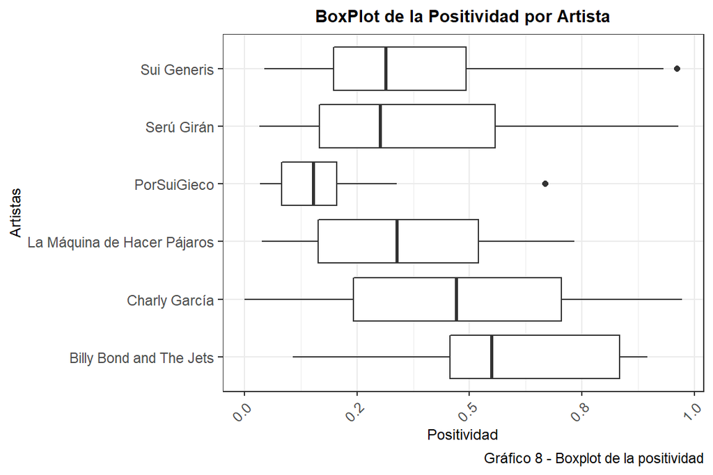

Después de haber evaluado el comportamiento de las variables cuantitativas por artista, se puede notar una anomalía en el artista PorSuiGieco que tiene energía y positividad en niveles mucho más bajos que el resto mientras que el nivel de acústica tiene valores notablemente más altos. Esto puede explicar la ausencia de sus canciones en el top 88. Investigando si existía alguna otra variable que podría explicar esta anomalía descubrimos que PorSuiGieco fue un supergrupo de folk rock argentino formado por importantes figuras del rock acústico argentino, lo que explica los niveles de acústica. Este reagrupe provenía de “Por” (Raúl Porchetto), “Sui” (Sui Generis), “Gieco” (León Gieco). Hicieron solo 3 conciertos y grabaron un solo disco. Concluyendo que al ser una banda que tenía influencia de otros artistas genere anomalías en las variables cuantitativas.

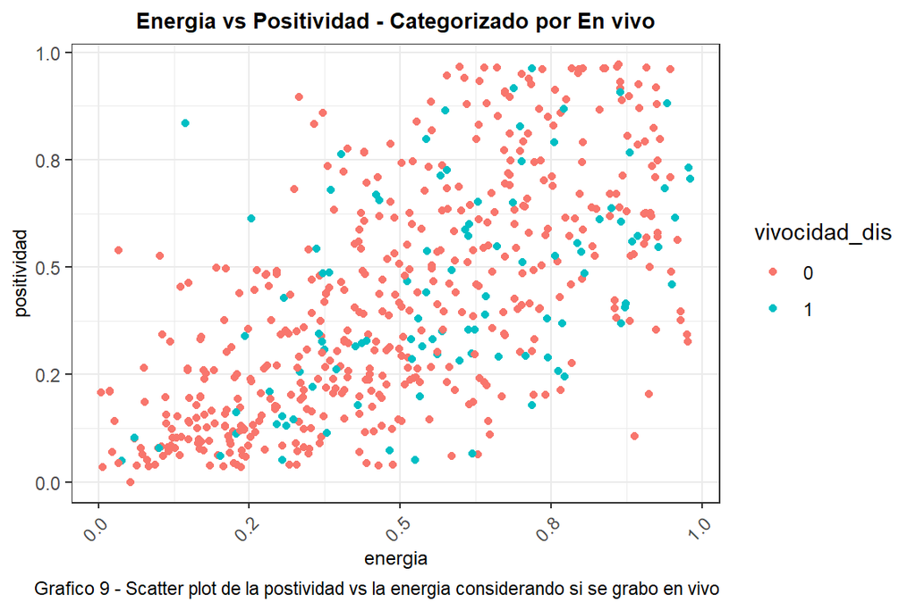

Este gráfico de puntos nos muestra algo que nos esperábamos, que es que a medida que la positividad de la canción es más alta también lo es su energía. El hecho de que la canción haya sido grabada en vivo, hace que no tengamos tantas canciones en vivo que tengan su energía menor a 0.25 y se encuentran en su mayoría por arriba de ese valor.

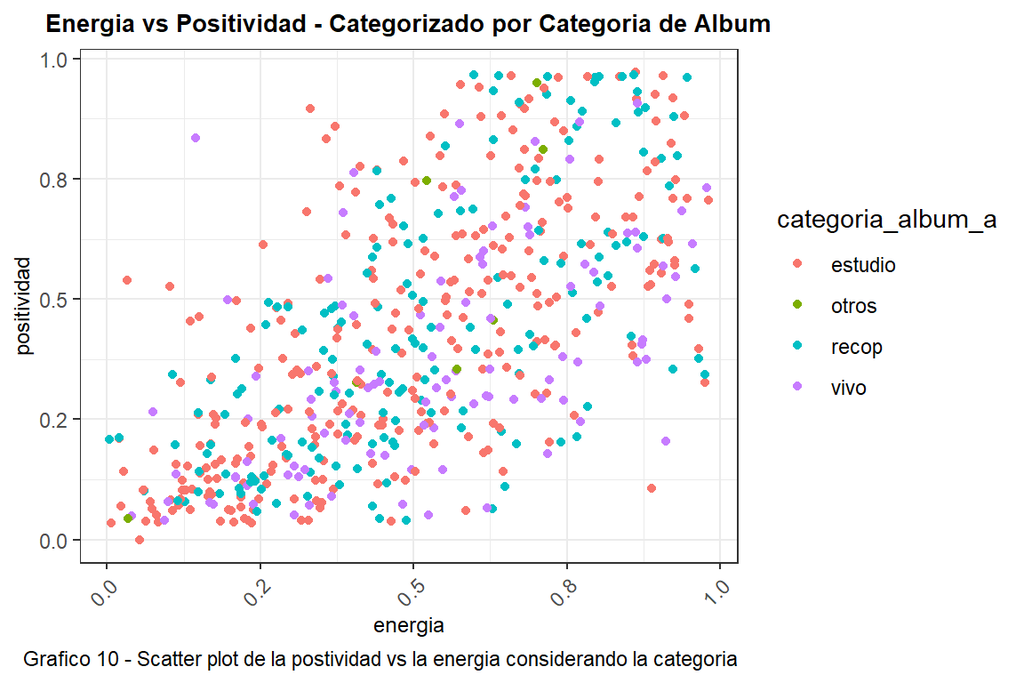

Vemos ahora lo mismo que antes, pero con los colores marcando el tipo de álbum. No encontramos nada destacable con respecto a estas dos medidas cuando consideramos la categoría del álbum en que se encuentran.

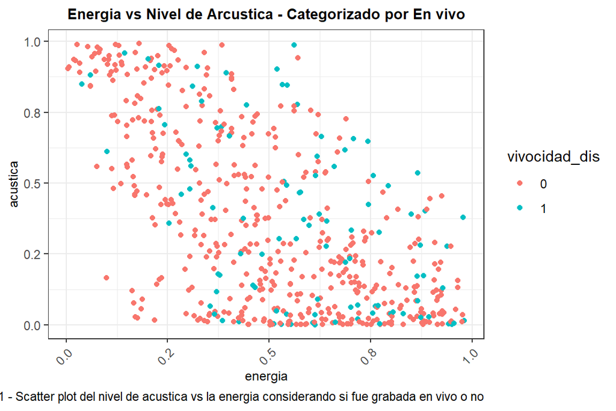

Aquí podemos ver que cuando el nivel de acústica es alto, la energía es mas baja y viceversa. Es decir, están inversamente relacionadas. Cuando consideramos si fue grabada en vivo o no, no encontramos nada destacable.

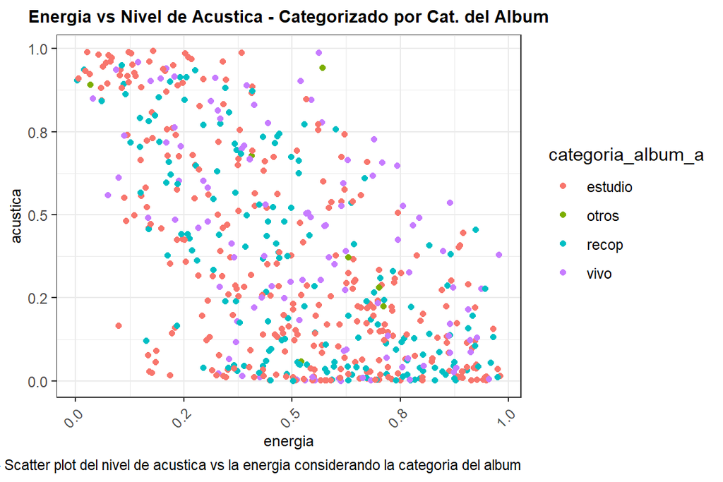

Aquí observamos lo mismo que antes, una vez más, la categoría del álbum no tiene influencia en ninguna de estas dos variables numéricas. Podemos destacar también, que tenemos muchas canciones con niveles de acústica bajos, focalizados cerca del cero.

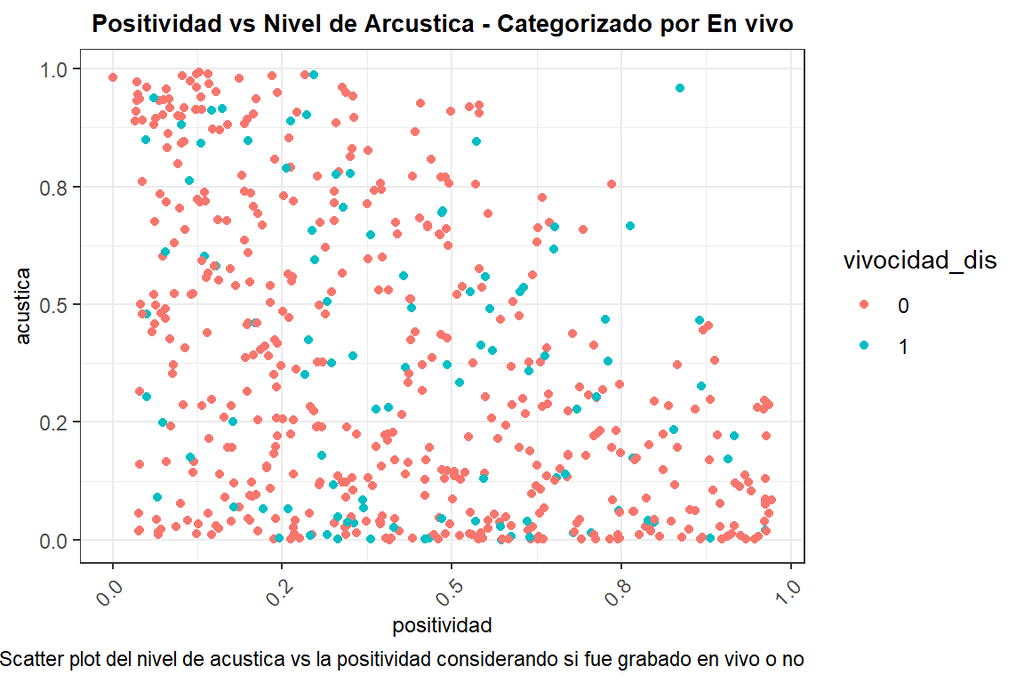

Cuando analizamos esta dos variables numéricas en conjunto, ya no encontramos una relación tan concreta, como sí vimos entre la energía y la positivdad. Algo que podemos destacar es que hay pocas canciones con valores altos de positividad y de acústica mientras que tenemos canciones que tienen valores bajos en ambas cercanos al 0.

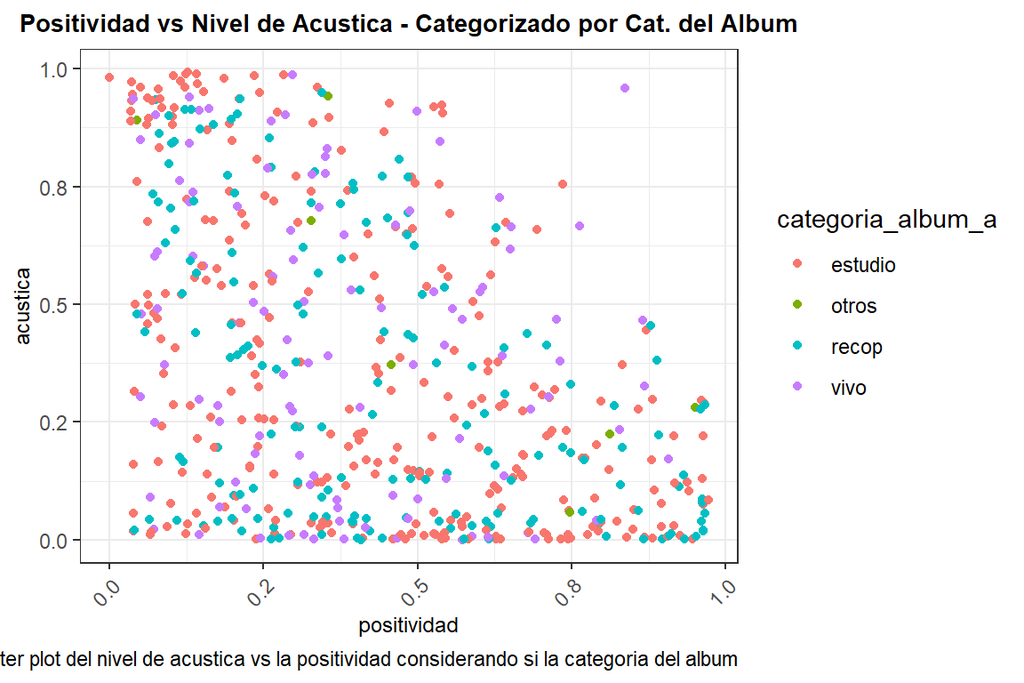

Si repetimos el mismo análisis, considerando ahora el tipo de álbum, no podemos sacar ninguna conclusión que resalte a simple vista.

En esta estapa del proyecto lo que vamos a analizar es el comportamiento de las variables cuantitativas seleccionadas con respecto a las variables cualitativas segmentando por Top cien.

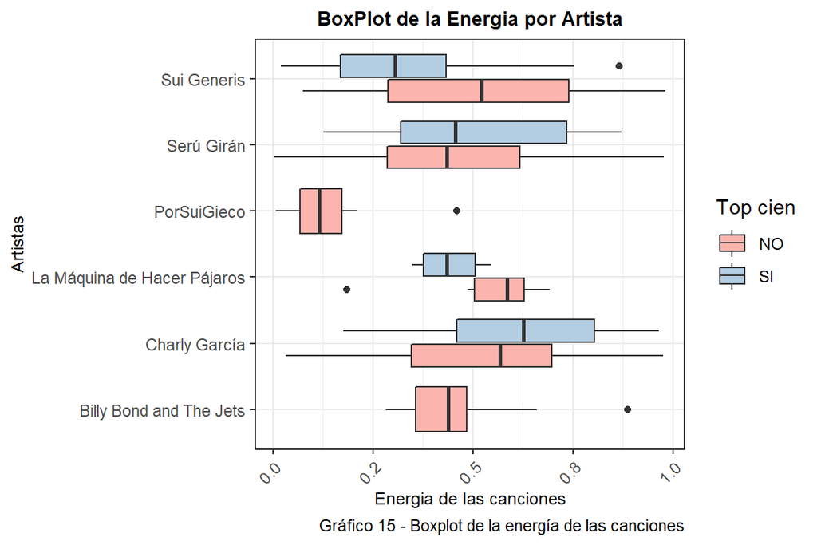

En las canciones exitosas no se detecta una tendencia marcada en la variable energía. Observando dentro de cada artista vemos las canciones exitosas de Sui Generis y la LMDHP tiene una energía menor. Mientras que Serú Girán y Solista tiene una energía similar.

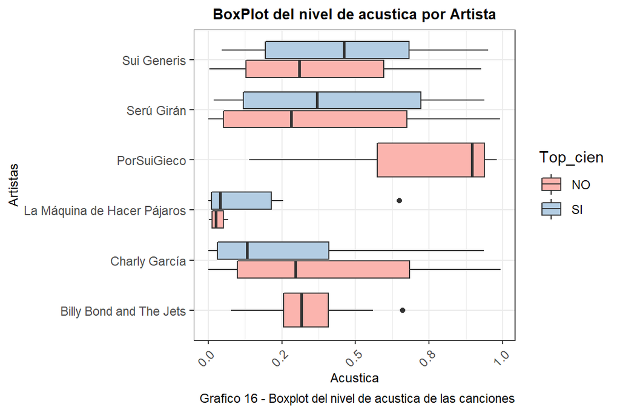

Respecto de la acústica, se puede obserbar un comportamiento similar comparando las canciones exitosas y las no exitosas dentro de cada artista. Tampoco se evidencia un comportamiento marcado para definir qué nivel de acústica tiene una canción exitosa.

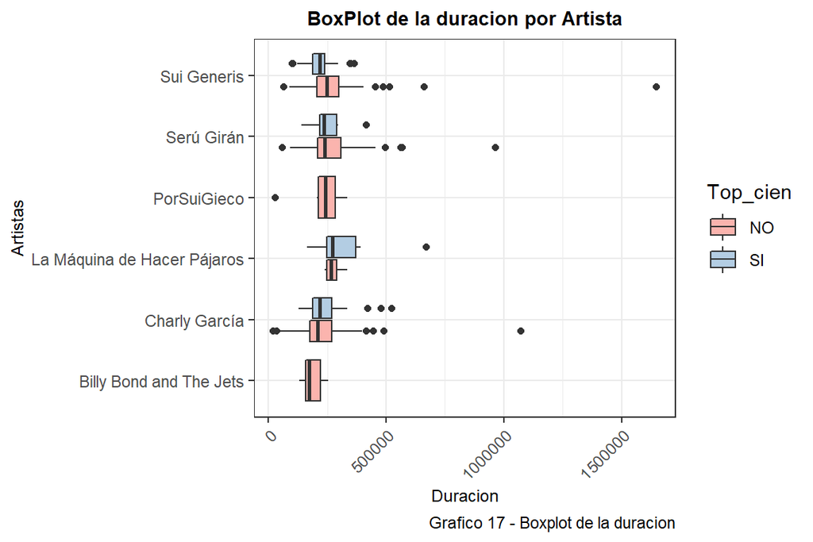

Este boxplot no nos muestra ninguna cuestión atípica en cuando a la duración de las canciones por cada artista y éxitos de las canciones.

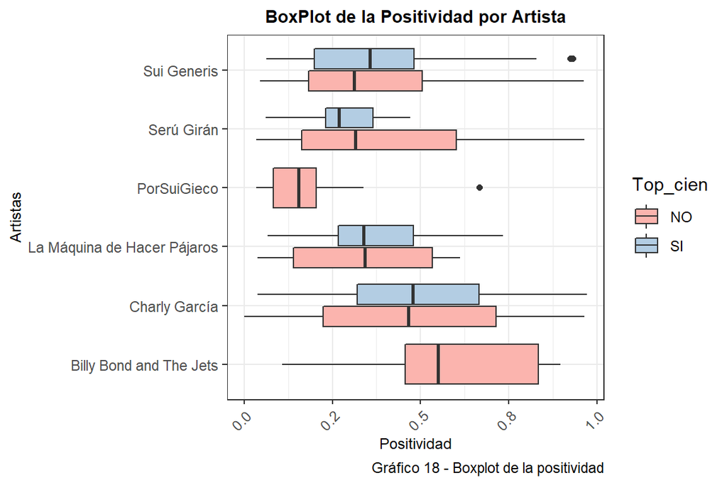

En esta segunda etapa, en la que se ha evaluado el comportamiento de las variables cuantitativas por artista, segmentado por canciones exitosos y no exitosas, ratificamos que PorSuiGieco tiene un comportamiento atípico. Es aún mas atípico comparando con los blox plots de las canciones exitosas. Destacando que no se evidencia un comportamiento uniforme en las canciones exitosas.

Ahora realizamos el mismo análisis de comparación de las variables cuantitativas, buscando patrones al segregar por canciones exitosas.

[figure not shown]

Este gráfico de puntos evidencia que las canciones exitosas y no exitosas tienen el mismo comportamiento en Energía vs Positividad.

[figure not shown]

Aquí tampoco evidenciamos un patrón con respecto a las canciones exitosas.

[figure not shown]

Finalizada esta segunda etapa de analisis, no encontramos patrones en la varibles segmentando por Top cien.

El último análisis que realizaremos, estará enfocado en analizar los nombres de las canciones del artista. Para ello haremos una nube de palabras:

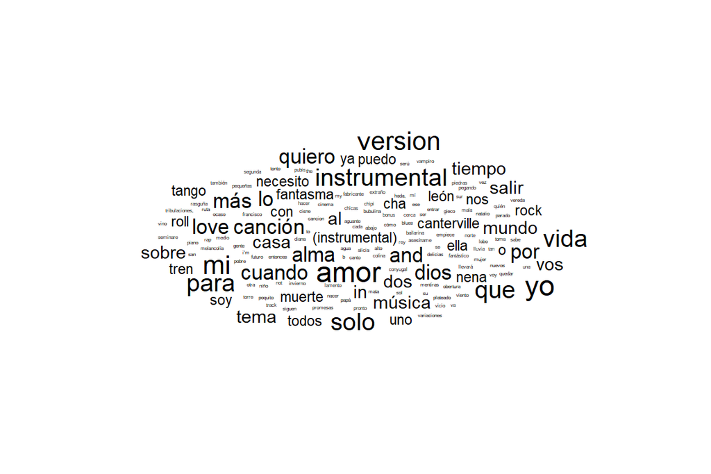

### Conclusiones

Luego indagamos en la cantidad de éxitos tuvo cada artista en relación a la cantidad de canciones publicadas. Sorprendiéndonos con La máquina de hacer pájaros que tuvo más del 50 % de éxito. Pero aún lo que más llamativo de esta primera parte fue observar cómo estaban distribuidos los éxitos dentro de las categorías, exponiendo la estrategia de marketing que utilizaron cuando conformaron los álbumes recopilatorios. En los cuales, combinan canciones de éxito con canciones no exitosas seguramente para asegurarse la venta.

Concluyendo, no podemos asegurar qué rango tiene que poseer una variable para que una canción sea exitosa, ya que no encontramos en los datos un patrón que lo indique. Esto se debe a que hay variables exógenas, como nivel de popularidad, que afectan al éxito de una canción. Sin embargo se observó que en el contexto actual, en el cual ya no se compran discos físicos y son populares plataformas como Spotify, la estrategia de marketing mencionada ya no es aplicable, y la misma quedara para los libros.